# assignment

jinyixin

Assignment 09-14

## Question 1

This example uses the inverse transform method to simulate a random sample from the distribution with density $f_X (x) = 3x^2 , 0 < x < 1$.

## Answer 1

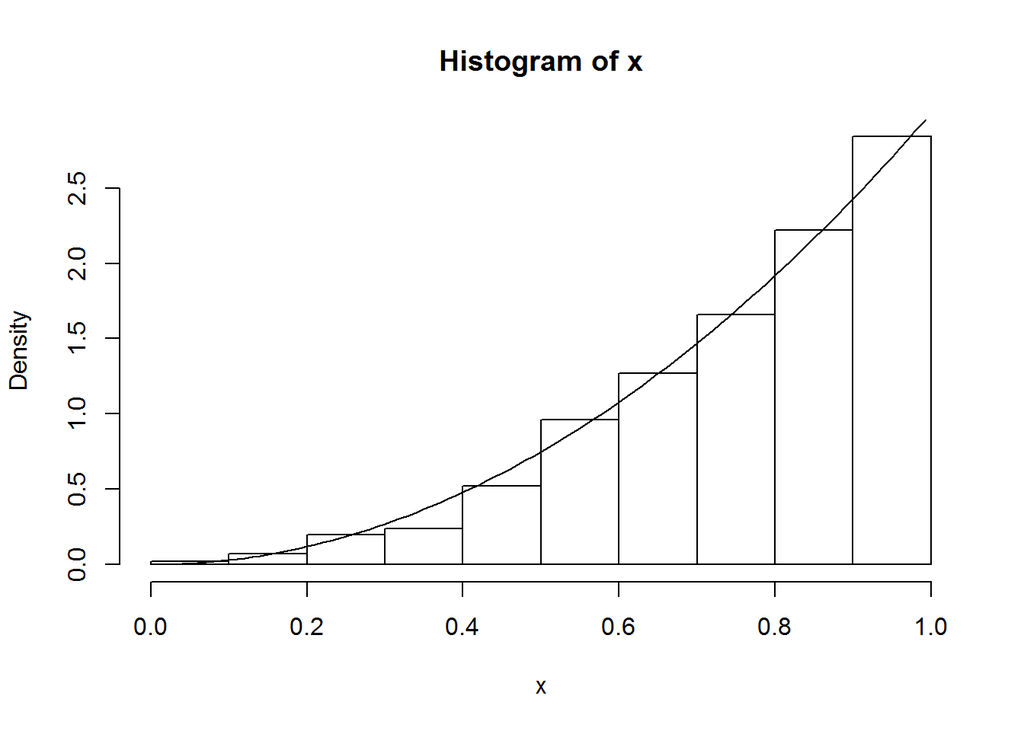

```r
n <- 1000
u <- runif(n)
x <- u^(1/3)
hist(x, prob = TRUE) #density histogram of sample
y <- seq(0, 1, .01)
lines(y, 3*y^2) #density curve f(x)
```

## Question 2

Generate random samples from a Logarithmic(0.5) distribution.

## Answer 2

```r
rlogarithmic <- function(n, theta) {
#returns a random logarithmic(theta) sample size n
u <- runif(n)
#set the initial length of cdf vector
N <- ceiling(-16 / log10(theta))
k <- 1:N
a <- -1/log(1-theta)
fk <- exp(log(a) + k * log(theta) - log(k))
Fk <- cumsum(fk)
x <- integer(n)
for (i in 1:n) {
x[i] <- as.integer(sum(u[i] > Fk)) #F^{-1}(u)-1
while (x[i] == N) {
#if x==N we need to extend the cdf
#very unlikely because N is large
logf <- log(a) + (N+1)*log(theta) - log(N+1)
fk <- c(fk, exp(logf))
Fk <- c(Fk, Fk[N] + fk[N+1])
N <- N + 1
x[i] <- as.integer(sum(u[i] > Fk))
}
}
x + 1
}
```

## Question 3

Let $X 1 ∼ Gamma(2, 2) $and $X 2 ∼ Gamma(2, 4) $be independent. Compare the histograms of the samples generated by the convolution $S = X_1 +X_2 $ and the mixture $F_X = 0.5F_{X_1} + 0.5F_{X_2}$ .

## Answer 3

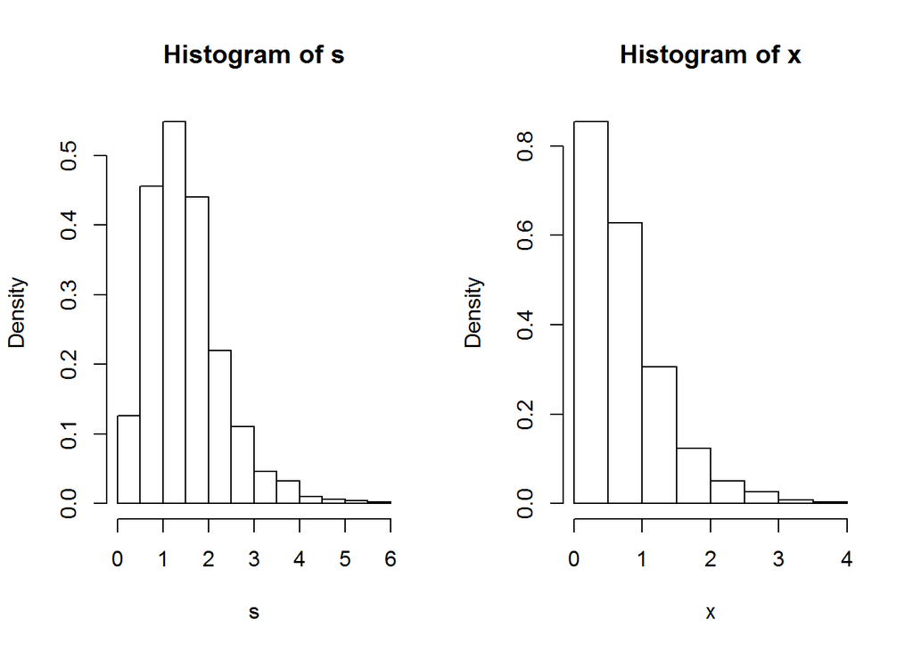

```r
n <- 1000
x1 <- rgamma(n, 2, 2)
x2 <- rgamma(n, 2, 4)
s <- x1 + x2 #the convolution
u <- runif(n)
k <- as.integer(u > 0.5) #vector of 0’s and 1’s
x <- k * x1 + (1-k) * x2 #the mixture
par(mfcol=c(1,2)) #two graphs per page
hist(s, prob=TRUE)
hist(x, prob=TRUE)
```

```r
par(mfcol=c(1,1)) #restore display
```

A discrete random variable X has probability mass function

```
##   0   1   2   3   4
## 0.1 0.2 0.2 0.2 0.3
```

Use the inverse transform method to generate a random sample of size 1000 from the distribution of X. Construct a relative frequency table and compare the empirical with the theoretical probabilities. Repeat using the R sample function.

## Answer 1

1. Use the inverse transform method to generate a random number from the distribution of X and compute the emperical frequency.

```r
set.seed(1)
x <- c(0,1,2,3,4); p <- c(0.1,0.2,0.2,0.2,0.3)
cp <- cumsum(p); m <- 1e3; r <- numeric(m)
r <- x[findInterval(runif(m),cp)+1]
ct <- as.vector(table(r))
emperical_frequency=ct/sum(ct) #compute the emprical frequency
```

2. use the R sample function to generate a random number from the distribution of X and compute the theoretical probablities.

```r
auto_generate = sample(c(0,1,2,3,4), size = 1000, replace = TRUE, prob = c(0.1,0.2,0.2,0.2,0.3))
ct <- as.vector(table(auto_generate))
emperical_frequency_sample=ct/sum(ct) #compute the theoretical probablities
```

3. compare the empirical with the theoretical probabilities.

```
##                                0     1     2     3     4
## theoretical_probablities   0.100 0.200 0.200 0.200 0.300
## emperical_frequency        0.096 0.197 0.227 0.176 0.304
## emperical_frequency_sample 0.102 0.199 0.202 0.180 0.317
```

We can find easily that emperical_frequency has little difference with theoretical_probablities, thus generating random number is sucessful. The answer to the question 1 is completed.

## Question 2

### exercise 3.7

Write a function to generate a random sample of size n from the Beta(a,b) distribution by the acceptance-rejection method. Generate a random sample of size 1000 from the Beta(3,2) distribution. Graph the histogram of the sample with the theoretical Beta(3,2) density superimposed.

## Answer 2

1. First, we define a function to generate a random sample of size n from the Beta(a,b) distribution by the acceptance-rejection method.

condition:Beta(a,b) with pdf $f(x) = \frac{\Gamma(a+b)}{\Gamma(a)\Gamma(b)}x^{a-1}(1-x)^{b-1}$, $0<x<1$ , $g(x) = 1$ , $0<x<1$ and $c = \frac{\Gamma(a+b)}{\Gamma(a)\Gamma(b)}$.

```r
generate_beta_random_variable <- function(a,b) {
    n <- 1e3;j<-k<-0;y <- numeric(n)
    while (k < n) {
      u <- runif(1)
      j <- j + 1
      x <- runif(1) #random variate from g
      if (x^(a-1) * (1-x)^(b-1) > u) {
        #we accept x
        k <- k + 1
        y[k] <- x
        }
    }
    hist( y, prob=T, ylab='', main='', breaks = "Scott")
    z=seq(0,1,.001)
    l=factorial(a+b-1)/(factorial(a-1)*factorial(b-1))*z^(a-1)*(1-z)^(b-1)
    lines(z,l)

}
```

2. Generating a random sample of size 1000 from the Beta(3,2) distribution and graph the histogram of the sample with the theoretical Beta(3,2) density superimposed.

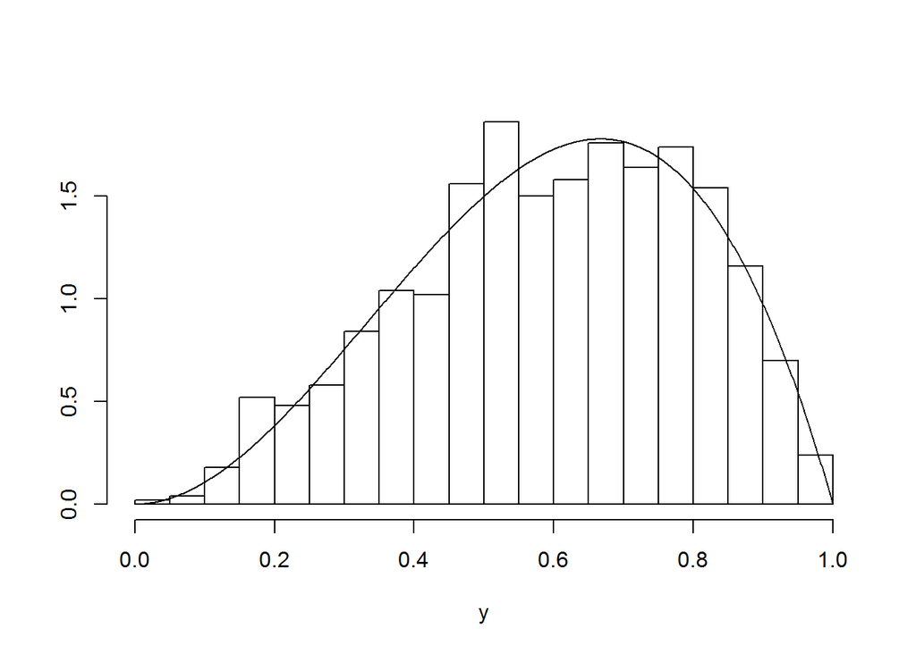

```r
generate_beta_random_variable(3,2)
```

According to the graph, random sample generating by code we write is almostly same as theoretical Beta(3,2) distribution. The answer to the question 2 is completed.

## Question 3

### exercise 3.12

Simulate a continuous Exponential-Gamma mixture. Suppose that the rate parameter $\Lambda$ has $Gamma(r,\beta)$ distribution and Y has $Exp( \Lambda )$ distribution. That is, $(Y | \Lambda = \lambda) ~ f_Y (y|\lambda) = \lambda) \exp^{-\lambda y}$. Generate 1000 random observations from this mixture with $r = 4$ and $\beta = 2$.

(Remark:because of Browser display incorrectly, I rewrite the question here just the same as the content above.) Simulate a continuous Exponential-Gamma mixture. Suppose that the rate parameter Λ has Gamma(r,β) distribution and Y has Exp(Λ) distribution. That is, (Y |Λ = λ) ∼ f Y (y|λ) = λe^(-λy) . Generate 1000 random observations from this mixture with r = 4 and β = 2.

## Answer 3

1. first of all we generate Lambda with Gamma(r,$\beta$) distribution.
2. Then we generate 1000 random observations from this mixture with r = 4 and $\beta$ = 2,and graph the histogram of the sample .

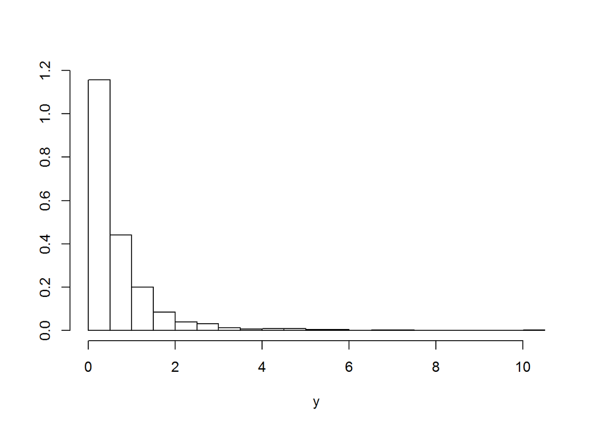

```r
n = 1000
r = 4
beta = 2
Lambda = rgamma( n,r,beta )
y = rexp( n,Lambda )
# graph the histogram
hist( y, prob=T, ylab='', main='', breaks = "Scott")
```

Assignment 09-30

## Question 1

### exercise 5.4

Write a function to compute a Monte Carlo estimate of the Beta(3, 3) cdf, and use the function to estimate F(x) for $x = 0.1,0.2,\dots,0.9$ . Compare the estimates with the values returned by the pbeta function in R.

## Answer 1

1. a function to compute a Monte Carlo estimate of the Beta(a, b) cdf.

```r
set.seed(1)
beta_cdf <- function(x,a,b) {
    u=runif(1000,min = 0,max = x)
    g = factorial(a+b-1)/(factorial(a-1)*factorial(b-1))*u^(a-1)*(1-u)^(b-1)
    theta = mean(x*g)
}
```

2. Let $a=3$ and $b=3$, we compare Beta(3,3) cdf for $x = 0.1,0.2,\dots,0.9$ generated from function we write and pbeta function in R respectively.

```r
x=seq(0.1,0.9,0.1)
for (i in x) {
  a = beta_cdf(i,3,3)

  b = pbeta(i,3,3)

  print(c(i,a,b))
}
```

```
## [1] 0.10000000 0.00854217 0.00856000
## [1] 0.2000000 0.0568632 0.0579200
## [1] 0.3000000 0.1587502 0.1630800
## [1] 0.4000000 0.3178384 0.3174400
## [1] 0.5000000 0.5059565 0.5000000
## [1] 0.6000000 0.7116578 0.6825600
## [1] 0.7000000 0.8580018 0.8369200
## [1] 0.8000000 0.9282974 0.9420800
## [1] 0.9000000 0.9945355 0.9914400
```

## Question 2

### exercise 5.9

The Rayleigh density is $f(x) = \frac{x}{\sigma^2}e^{-x^2/(2\sigma^2)} , x \geq 0,\sigma >0$. Implement a function to generate samples from a Rayleigh($\sigma$) distribution, using antithetic variables. What is the percent reduction in variance of $\frac{X+X^{'}}{2}$ compared with$\frac{X_1+X_2}{2}$ for independent $X_1,X_2$ ?

## Answer 2

according to the Rayleigh distribution density function, we calculate the cdf of Rayleigh distribution $F(x)=1-e^{-\frac{x^2}{2\sigma^2}}$.

1. we write functions to generate random number from Rayleigh distribution with inverse transform method and antithetic variables respectively.

```r
generate_Rayleigh_random_variable = function(sigma){
    n = 1000
    x = runif(n)
    g = (-2*sigma^2*log(1-x))^(1/2)
    return(g)
}


generate_Rayleigh_random_variable_antithetic_variable = function(sigma){
    n = 1000
    x = runif(n)
    g = (-2*sigma^2*log(1-x))^(1/2)
    f = (-2*sigma^2*log(x))^(1/2)
    return(c(g,f))
}
```

2. Let $\sigma=0.5$, and we use antithetic variables to generate z_1($z_1=\frac{X+X^{'}}{2}$), and we alse generate random number with inverse transform method for independent $X_1$ , $X_2$.

```r
set.seed(100)
a= generate_Rayleigh_random_variable_antithetic_variable(0.5)
z=numeric(1000)
for(i in seq(1,1000,1)){
  z[i]=a[i]+a[1000+i]
}
z_1=z/2
print(sprintf('variance of random sample with antithetic variable: %f',var(z_1)))
```

```
## [1] "variance of random sample with antithetic variable: 0.003279"
```

```r
x_1 = generate_Rayleigh_random_variable(0.5)
x_2 = generate_Rayleigh_random_variable(0.5)
z_2 = (x_1 + x_2)/2
print(sprintf('variance of random sample with independent variable: %f',var(z_2)))
```

```
## [1] "variance of random sample with independent variable: 0.055252"
```

```r
percent_reduction = (var(z_2) - var(z_1))/var(z_2)
print(sprintf('percent_reduction is: %s',paste(round(percent_reduction,6)*100,'%',sep = '')))
```

```
## [1] "percent_reduction is: 94.0659%"
```

Assignment 10-12

## Question 1

### exercise 6.9

Let X be a non-negative random variable with $\mu = E[X] < \infty$. For a random sample $x_1 ,\dots,x_n$ from the distribution of X, the Gini ratio is defined by $G=\frac{1}{2n^2\mu}\sum_{j=1}^n \sum_{i=1}^{n} |x_i - x_j|$. The Gini ratio is applied in economics to measure inequality in income dis- tribution (see e.g. [163]). Note that G can be written in terms of the order statistics x (i) as $G=\frac{1}{n^2\mu} \sum_{i=1}^{n} (2i-n-1)x_{(i)}$. If the mean is unknown, let $\hat{G}$ be the statistic G with $\mu$ replaced by $\bar{x}$. Estimate by simulation the mean, median and deciles of $\hat{G}$ if X is standard lognormal. Repeat the procedure for the uniform distribution and Bernoulli(0.1). Also construct density histograms of the replicates in each case.

## Answer 1

1. Write a function to compute gini ratio.

```r
set.seed(1)
n=1000
gini_ratio_computing = function(x,mu){
  x=sort(x)
  gini_ratio=0
  a=0
  for (i in 1:n) {
      if(mu==FALSE){
        mu=mean(x)
      }
      a=a+(2*i-n-1)*x[i]
  }

  gini_ratio=a/(n^2*mu)
  return(gini_ratio)
}
```

2. simulation the mean, median and deciles of $\hat{G}$ when X is lognormal distribution.

```r
k=1
gini_ratio_statistic_for_lognormal=numeric(n)
while (k<1001) {
  y=rnorm(n)
  x=exp(y)
  gini_ratio_statistic_for_lognormal[k]=gini_ratio_computing(x,1/2)
  k=k+1
}

decile=seq(0.1,1,by=0.1)
gini_ratio_hat_for_lognormal_mean=mean(gini_ratio_statistic_for_lognormal)
gini_ratio_hat_for_lognormal_median=median(gini_ratio_statistic_for_lognormal)
gini_ratio_hat_for_lognormal_deciles=quantile(gini_ratio_statistic_for_lognormal,decile)
print(sprintf('gini ratio for lognormal mean: %f, median:%f ', gini_ratio_hat_for_lognormal_mean,gini_ratio_hat_for_lognormal_median ))
```

```
## [1] "gini ratio for lognormal mean: 1.714195, median:1.715001 "
```

```r
print( gini_ratio_hat_for_lognormal_deciles)
```

```
##      10%      20%      30%      40%      50%      60%      70%      80%
## 1.580543 1.623798 1.653681 1.686864 1.715001 1.740375 1.768026 1.796487
##      90%     100%
## 1.848420 2.199099
```

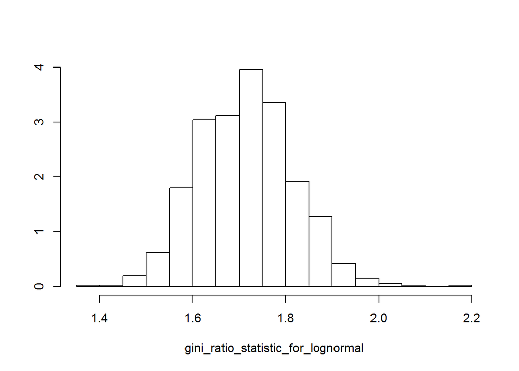

```r
hist(gini_ratio_statistic_for_lognormal, prob=T, ylab='', main='', breaks = "Scott")
```

3. simulation the mean, median and deciles of $\hat{G}$ when X is uniform distribution.

```r
k=1
gini_ratio_statistic_for_uniform=numeric(n)
while (k<1001) {
  x=runif(n)
  gini_ratio_statistic_for_uniform[k]=gini_ratio_computing(x,1/2)
  k=k+1
}

decile=seq(0.1,1,by=0.1)
gini_ratio_hat_for_uniform_mean=mean(gini_ratio_statistic_for_uniform)
gini_ratio_hat_for_uniform_median=median(gini_ratio_statistic_for_uniform)
gini_ratio_hat_for_uniform_deciles=quantile(gini_ratio_statistic_for_uniform,decile)
print(sprintf('gini ratio for uniform mean: %f, median: %f ', gini_ratio_hat_for_uniform_mean,gini_ratio_hat_for_uniform_median ))
```

```
## [1] "gini ratio for uniform mean: 0.333273, median: 0.333250 "
```

```r
print(gini_ratio_hat_for_uniform_deciles)
```

```
##       10%       20%       30%       40%       50%       60%       70%
## 0.3275633 0.3293651 0.3308929 0.3318948 0.3332496 0.3346069 0.3356915
##       80%       90%      100%
## 0.3372537 0.3390472 0.3494123
```

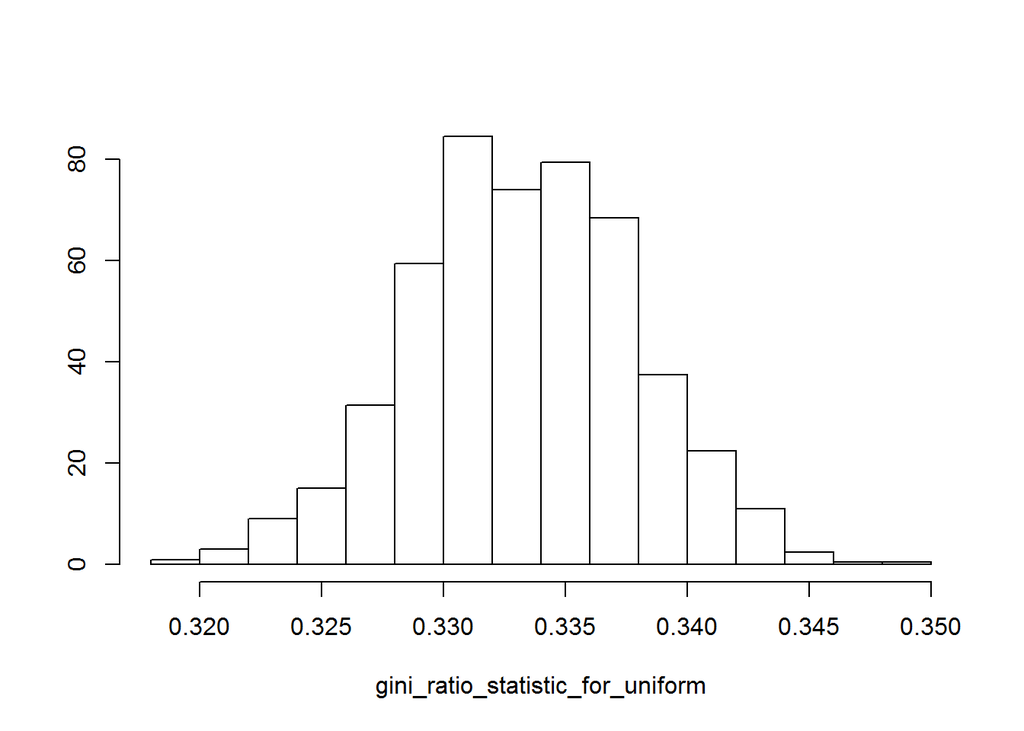

```r
hist(gini_ratio_statistic_for_uniform, prob=T, ylab='', main='', breaks = "Scott")
```

4. simulation the mean, median and deciles of $\hat{G}$ when X is Bernoulli(0.1) distribution.

```r
gini_ratio_statistic_for_bernoulli=numeric(n)
l=1
while (l<1001) {
  x=rbinom(n,1,0.1)
  gini_ratio_statistic_for_bernoulli[l]=gini_ratio_computing(x,0.1)
  l=l+1
}
decile=seq(0.1,1,by=0.1)
gini_ratio_hat_for_bernoulli_mean=mean(gini_ratio_statistic_for_bernoulli)
gini_ratio_hat_for_bernoulli_median=median(gini_ratio_statistic_for_bernoulli)
gini_ratio_hat_for_bernoulli_deciles=quantile(gini_ratio_statistic_for_bernoulli,decile)
print(sprintf('gini ratio for lognormal mean: %f, median:%f ', gini_ratio_hat_for_bernoulli_mean,gini_ratio_hat_for_bernoulli_median ))
```

```
## [1] "gini ratio for lognormal mean: 0.896680, median:0.900000 "
```

```r
print(gini_ratio_hat_for_bernoulli_deciles)
```

```
##     10%     20%     30%     40%     50%     60%     70%     80%     90%
## 0.79431 0.83536 0.85975 0.88396 0.90000 0.91596 0.93184 0.95551 0.99456
##    100%
## 1.10871
```

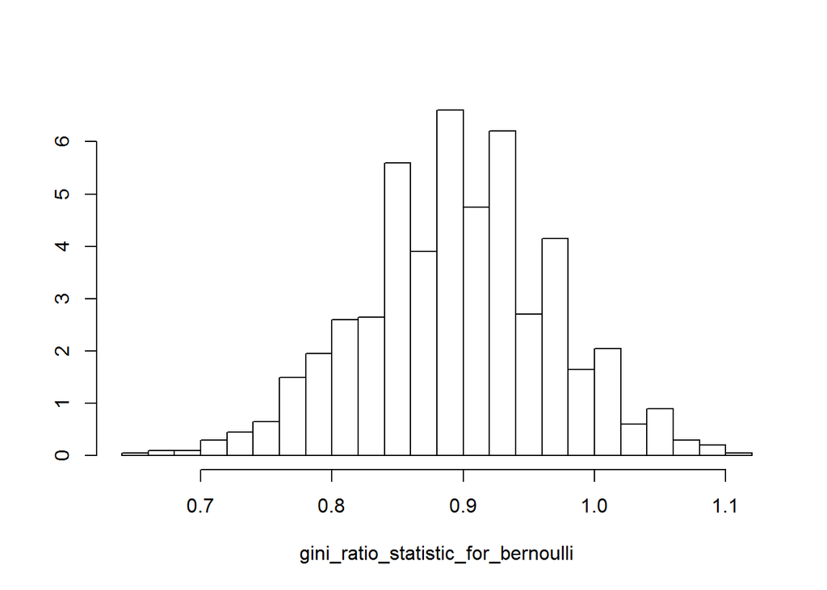

```r
hist(gini_ratio_statistic_for_bernoulli, prob=T, ylab='', main='', breaks = "Scott")
```

## Question 2

### exercise 6.10

Construct an approximate 95% confidence interval for the Gini ratio $\gamma = E[G]$ if X is lognormal with unknown parameters. Assess the coverage rate of the estimation procedure with a Monte Carlo experiment.

## Answer 2

We try to use central limit theorey to compute gini ratio hat confidence interval with a lot of simulations to generate indenpendent identical distribution random varible gini ratio hat.

```r
n=200
m=80
alpha=0.5
upper_confidence=numeric(n)
lower_confidence=numeric(n)
for (j in 1:n) {
  gini_ratio_hat=numeric(n)
  for (i in 1:m) {
    y = rnorm(n,mean = 0,sd=1)
    x = exp(y)
    gini_ratio_hat[i]=gini_ratio_computing(x,mu=FALSE)
  }
  gini_ratio_hat_mean=mean(gini_ratio_hat)
  upper_confidence[j]=gini_ratio_hat_variance = var(gini_ratio_hat)
  lower_confidence[j]=gini_ratio_hat_mean+(gini_ratio_hat_variance/m)^(1/2)*qnorm(1-alpha/2)

}
upper_confidence=mean(upper_confidence)
lower_confidence=mean(lower_confidence)
print(sprintf('confidence interval of gini ratio hat is :(%f , %f)',upper_confidence,lower_confidence ))
```

```
## [1] "confidence interval of gini ratio hat is :(0.064719 , 0.225815)"
```

## Question 3

### exercise 6.B

Tests for association based on Pearson product moment correlation $\rho$, Spearman’s rank correlation coefficient $\rho_s$ , or Kendall’s coefficient $\tau$, are implemented in cor.test. Show (empirically) that the nonparametric tests based on $\rho_s$ or $\tau$ are less powerful than the correlation test when the sampled distribution is bivariate normal. Find an example of an alternative (a bivariate distribution (X,Y ) such that X and Y are dependent) such that at least one of the nonparametric tests have better empirical power than the correlation test against this alternative.

## Answer 3

1.nonparametric tests based on $\rho_s$ or $\tau$ are less powerful than the correlation test when the sampled distribution is bivariate normal

```r
set.seed(1)
library(MASS)
m <- 1000
pvalues <- replicate(m, expr = {
  Sigma = matrix(c(12,2,2,1),2,2)
  bivarite_normal=mvrnorm(n=50, rep(0, 2), Sigma)
  x=bivarite_normal[1:50,1]
  y=bivarite_normal[1:50,2]
  pearson_test <- cor.test(x,y,method = "pearson")
  spearman_test = cor.test(x,y,method = 'spearman')
  kendall_test = cor.test(x,y,method = 'kendall')
  c(pearson_test$p.value,spearman_test$p.value,kendall_test$p.value) } )

power_pearson = mean(pvalues[1,1:1000] < 0.05)
power_spearman= mean(pvalues[2,1:1000] < 0.05)
power_kendall = mean(pvalues[3,1:1000]<0.05)
power_pearson
```

```
## [1] 0.994
```

```r
power_spearman
```

```
## [1] 0.99
```

```r
power_kendall
```

```
## [1] 0.988
```

Obviously, the correlation test when the sampled distribution is bivariate normal is more powerful than tests based on $\rho_s$ or $\tau$.

2. an example of an alternative (a bivariate distribution (X,Y) such that X and Y are dependent) such that at least one of the nonparametric tests have better empirical power than the correlation test against this alternative.

```r
set.seed(1)
library(MASS)
m <- 1000
pvalues <- replicate(m, expr = {
  Sigma = matrix(c(9,2,2,1),2,2)
  bivarite_normal=mvrnorm(n=50, rep(0, 2), Sigma)
  x=bivarite_normal[1:50,1]
  y=bivarite_normal[1:50,2]
  pearson_test <- cor.test(x,y,method = "pearson")
  spearman_test = cor.test(x,y,method = 'spearman')
  kendall_test = cor.test(x,y,method = 'kendall')
  c(pearson_test$p.value,spearman_test$p.value,kendall_test$p.value) }
)

power_pearson = mean(pvalues[1,1:1000] < 0.05)
power_spearman= mean(pvalues[2,1:1000] < 0.05)
power_kendall = mean(pvalues[3,1:1000]<0.05)
power_pearson
```

```
## [1] 0.998
```

```r
power_spearman
```

```
## [1] 0.999
```

```r
power_kendall
```

```
## [1] 0.999
```

Assignment 11-02

## Question 1

Compute a jackknife estimate of the bias and the standard error of the correlation statistic in Example 7.2.

## Answer 1

```r
library(bootstrap)
LSAT=law$LSAT
GPA=law$GPA
n = length( LSAT ) #numbeer of data
cor_jack = numeric( n )
cor_hat = cor( LSAT,GPA ) #corelation of LSAT  and GPA
```

```r
for (i in 1:n) { cor_jack[i] = cor( LSAT[-i],GPA[-i] ) }
bias_jack = (n-1)*( mean(cor_jack) - cor_hat )
cor_bar = mean(cor_jack) # mean of statistic generated from jackknife
se_jack = sqrt( (n-1)*mean( (cor_jack-cor_bar)^2 ) )

print(sprintf('estimate of the bias  of the correlation statistic is: %f',bias_jack ))
```

```
## [1] "estimate of the bias  of the correlation statistic is: -0.006474"
```

```r
print(sprintf('estimate of the standard error of the correlation statistic is: %f',se_jack ))
```

```
## [1] "estimate of the standard error of the correlation statistic is: 0.142519"
```

## Question 2

Refer to Exercise 7.4. Compute 95% bootstrap confidence intervals for the mean time between failures $\frac{1}{\lambda}$ by the standard normal, basic, percentile, and BCa methods. Compare the intervals and explain why they may differ.

## Answer 2

```r
library(boot)
attach(aircondit)
x = hours
B = 5000
set.seed(1)
```

```r
gaptime_hat = mean(x) #MLE of 1/lambda
#bootstrap estimate of 1/lambda
frac_1_lambda_boot = boot(data=aircondit,statistic=function(x,i){mean(x[i,])}, R=B )

frac_1_lambda_boot
```

```
##
## ORDINARY NONPARAMETRIC BOOTSTRAP
##
##
## Call:
## boot(data = aircondit, statistic = function(x, i) {
##     mean(x[i, ])
## }, R = B)
##
##
## Bootstrap Statistics :
##     original  bias    std. error
## t1* 108.0833  0.2438    37.77646
```

We see the MLE is 1/lambda = 108.0833, with estimated std. error = 37.77646, bias = 0.2438.

Next we try to calculate the bootstrap intervals by the standard normal, basic, percentile, and BCa methods.

```r
einf_jack = empinf(frac_1_lambda_boot, type='jack')
boot.ci( frac_1_lambda_boot, type=c('norm','basic','perc','bca'), L=einf_jack )
```

```
## BOOTSTRAP CONFIDENCE INTERVAL CALCULATIONS
## Based on 5000 bootstrap replicates
##
## CALL :
## boot.ci(boot.out = frac_1_lambda_boot, type = c("norm", "basic",
##     "perc", "bca"), L = einf_jack)
##
## Intervals :
## Level      Normal              Basic
## 95%   ( 33.8, 181.9 )   ( 25.8, 170.5 )
##
## Level     Percentile            BCa
## 95%   ( 45.7, 190.3 )   ( 54.9, 222.2 )
## Calculations and Intervals on Original Scale
```

We see the intervals are quite different. A primary reason is that the bootstrap distribution is still skewed, affecting the simpler methods and their appeal to the Central Limit Theorem. For example

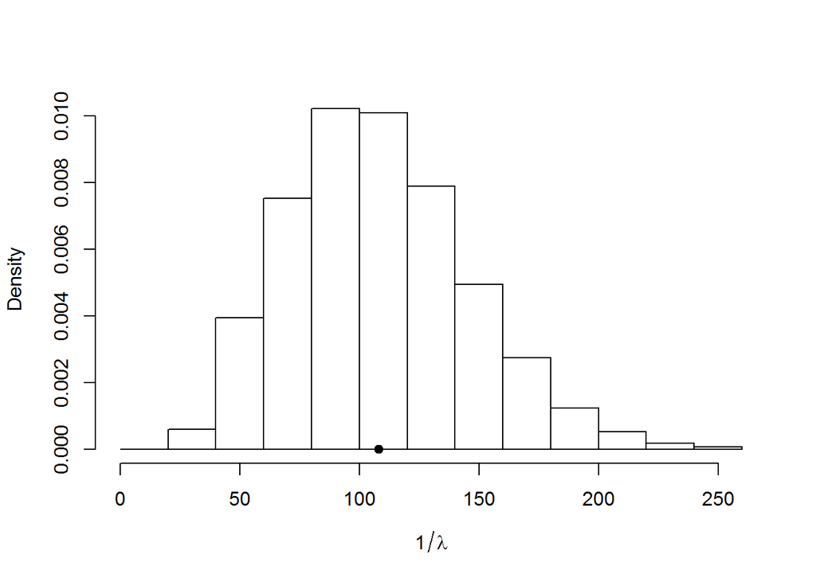

```r
hist(frac_1_lambda_boot$t, main='', xlab=expression(1/lambda), prob=T)
points(frac_1_lambda_boot$t0, 0, pch = 19)
```

The BCa interval incorporates an acceleration adjustment for skew, and may be preferred here.

## Question 3

Refer to Exercise 7.7. Obtain the jackknife estimates of bias and standard error of $\hat{\theta}$.

## Answer 3

```r
library(bootstrap)
attach( scor )
n = length( scor[,1] )
x = as.matrix(scor)
theta_jack = numeric( n )
```

```r
lambda_hat = eigen(cov(scor))$values
theta_hat = lambda_hat[1]/sum(lambda_hat) #compute the mean of theta from sample
#according to the formala, we write a function to calculate the theta.
theta = function(x){
 eigen(cov(x))$values[1]/sum(eigen(cov(x))$values)
}

for (i in 1:n) { theta_jack[i] = theta( x[-i,] ) }

theta_bar = mean(theta_jack)
bias_jack = (n-1)*( mean(theta_jack) - theta_hat )
se_jack = sqrt( (n-1)*mean( (theta_jack-theta_bar)^2 ) )

print(sprintf('the jackknife estimates of bias of hat of theta is : %f', bias_jack))
```

```
## [1] "the jackknife estimates of bias of hat of theta is : 0.001069"
```

```r
print(sprintf('the jackknife estimates of standard error of hat of theta is : %f', se_jack))
```

```
## [1] "the jackknife estimates of standard error of hat of theta is : 0.049552"
```

```r
detach(scor)
```

## Question 4

In Example 7.18, leave-one-out (n-fold) cross validation was used to select the best fitting model. Use leave-two-out cross validation to compare the models.

## Answer 4

The code to estimate the parameters of the four models follows. Plots of the predicted response with the data are also constructed for each model and shown follows.

```r
library(DAAG)
```

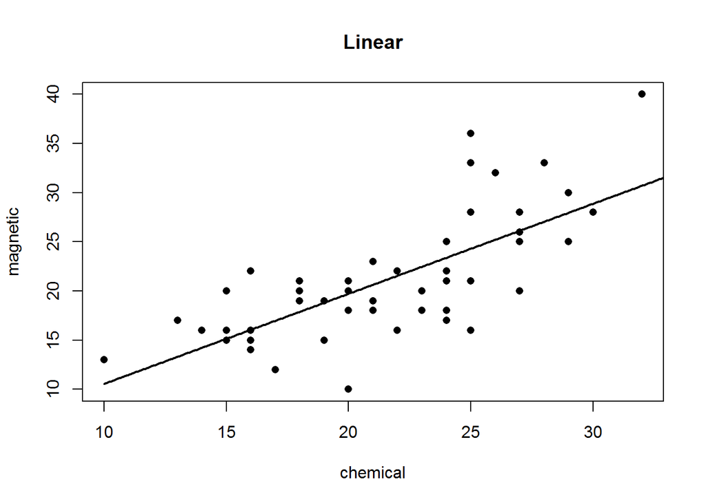

```r
attach(ironslag)
a <- seq(10, 40, .1) #sequence for plotting fits

L1 <- lm(magnetic ~ chemical)
plot(chemical, magnetic, main="Linear", pch=16)
yhat1 <- L1$coef[1] + L1$coef[2] * a
lines(a, yhat1, lwd=2)
```

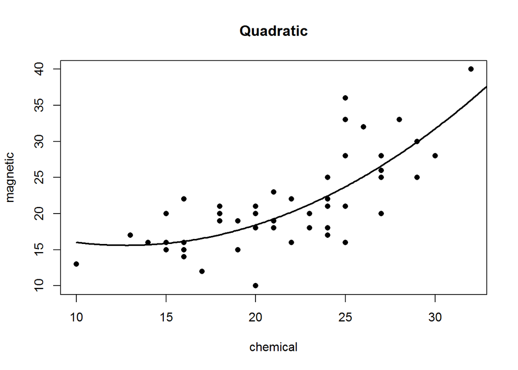

```r
L2 <- lm(magnetic ~ chemical + I(chemical^2))
plot(chemical, magnetic, main="Quadratic", pch=16)
yhat2 <- L2$coef[1] + L2$coef[2] * a + L2$coef[3] * a^2
lines(a, yhat2, lwd=2)
```

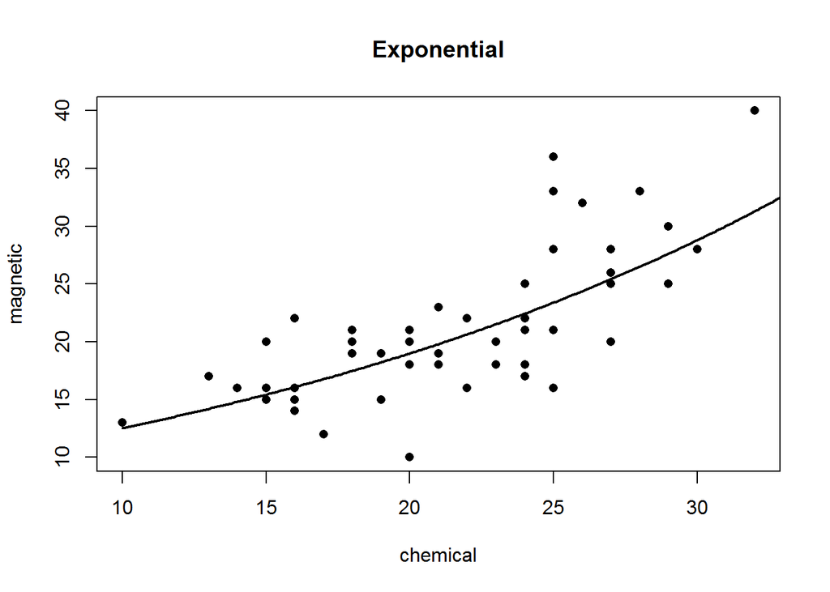

```r
L3 <- lm(log(magnetic) ~ chemical)
plot(chemical, magnetic, main="Exponential", pch=16)
logyhat3 <- L3$coef[1] + L3$coef[2] * a
yhat3 <- exp(logyhat3)
lines(a, yhat3, lwd=2)
```

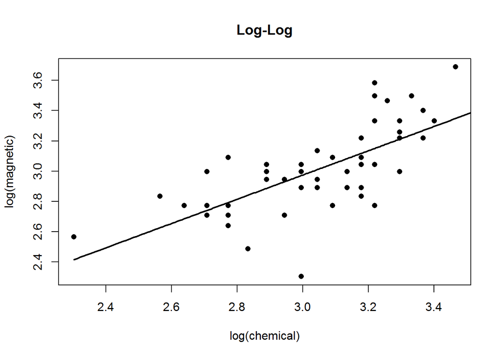

```r
L4 <- lm(log(magnetic) ~ log(chemical))
plot(log(chemical), log(magnetic), main="Log-Log", pch=16)
logyhat4 <- L4$coef[1] + L4$coef[2] * log(a)
lines(log(a), logyhat4, lwd=2)
```

Once the model is estimated, we want to assess the fit. Cross validation can be used to estimate the prediction errors.

```r
n <- length(magnetic)
e1 <- e2 <- e3 <- e4 <- numeric(n)
k=1
# fit models on leave-two-out samples

while (k<n) {
    y <- magnetic[c(-k,-(k+1))]
    x <- chemical[c(-k,-(k+1))]

    J1 <- lm(y ~ x)
    yhat1 <- J1$coef[1] + J1$coef[2] * chemical[k]
    e1[k] <- magnetic[k] - yhat1

    J2 <- lm(y ~ x + I(x^2))
    yhat2 <- J2$coef[1] + J2$coef[2] * chemical[k] +
    J2$coef[3] * chemical[k]^2
    e2[k] <- magnetic[k] - yhat2

    J3 <- lm(log(y) ~ x)
    logyhat3 <- J3$coef[1] + J3$coef[2] * chemical[k]
    yhat3 <- exp(logyhat3)
    e3[k] <- magnetic[k] - yhat3

    J4 <- lm(log(y) ~ log(x))
    logyhat4 <- J4$coef[1] + J4$coef[2] * log(chemical[k])
    yhat4 <- exp(logyhat4)
    e4[k] <- magnetic[k] - yhat4

    k=k+2
}
```

The following estimates for prediction error are obtained from the leave two out cross validation.

```r
c(mean(e1^2), mean(e2^2), mean(e3^2), mean(e4^2))
```

```
## [1] 8.505391 6.762961 7.362525 8.780626
```

According to the prediction error criterion, Model 2, the quadratic model, would be the best fit for the data.

```r
L2
```

```
##
## Call:
## lm(formula = magnetic ~ chemical + I(chemical^2))
##
## Coefficients:
##   (Intercept)       chemical  I(chemical^2)
##      24.49262       -1.39334        0.05452
```

The fitted regression equation for Model 2 is
$$\hat{Y} = 24.49262 - 1.39334X + 0.05452X^2$$

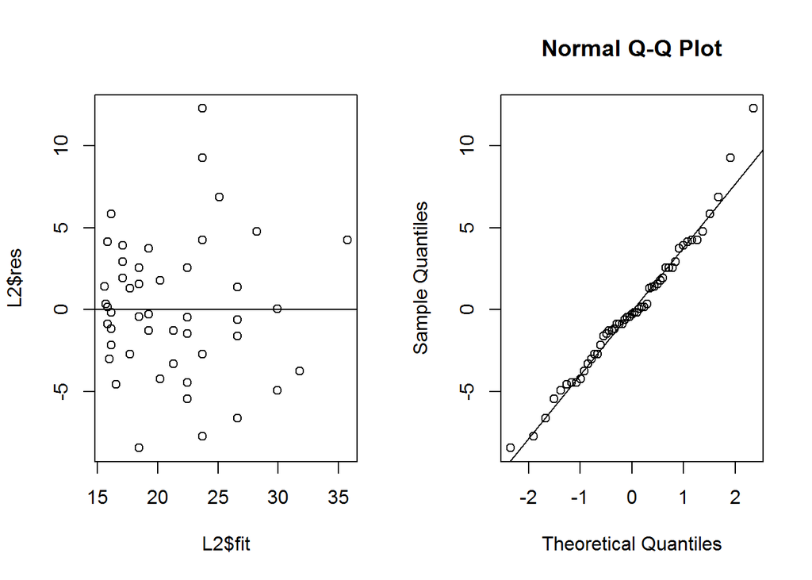

```r
par(mfrow = c(1, 2)) #layout for graphs
plot(L2$fit, L2$res) #residuals vs fitted values
abline(0, 0) #reference line
qqnorm(L2$res) #normal probability plot
qqline(L2$res) #reference line
```

```r
par(mfrow = c(1, 1)) #restore display
```

Assignment 11-16

## Question 1

Implement the two-sample Cram´ er-von Mises test for equal distributions as a permutation test. Apply the test to the data in Examples 8.1 and 8.2.

## Answer 1

1.Initial parameters

```r
set.seed(1)
library(cramer)
attach(chickwts)
x <- sort(as.vector(weight[feed == "soybean"]))
y <- sort(as.vector(weight[feed == "linseed"]))
R <- 99 #number of replicates
z <- c(x, y) #pooled sample
K <- 1:26
W_2_hat =numeric(R) #storage for replicates
```

2.Generate samples and calculat p value with permutation method.

```r
W_2_0 = cramer.test(x,y)$statistic
for (i in 1:R) {
    #generate indices k for the first sample
    k <- sample(K, size = 14, replace = FALSE)
    x1 <- z[k]
    y1 <- z[-k] #complement of x1
    W_2_hat[i] = cramer.test(x1,y1)$statistic
}
p <- mean(abs(c(W_2_0, W_2_hat)) >= W_2_0)
round(c(p,cramer.test(x,y)$p.value),3)
```

```
## [1] 0.400 0.381
```

3.Draw the histgram

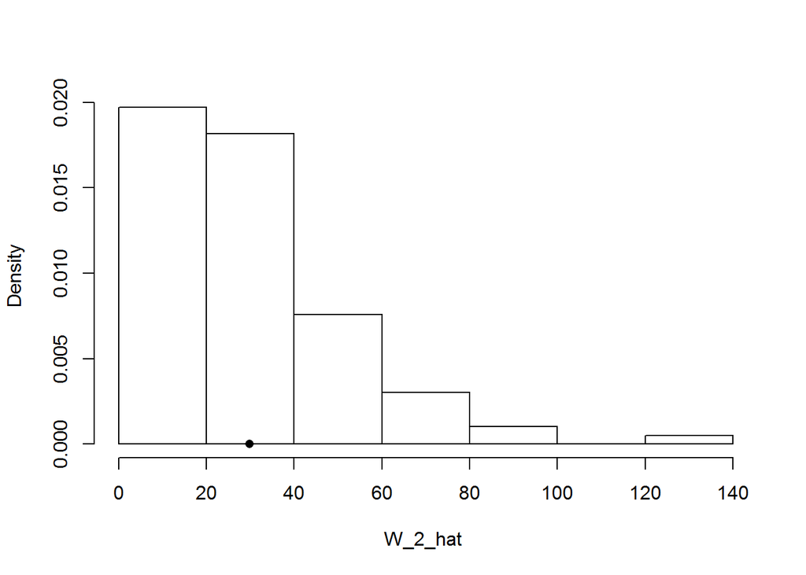

```r
hist(W_2_hat, main = "", freq = FALSE, xlab = "W_2_hat ",
breaks = "scott")
points(W_2_0, 0, cex = 1, pch = 16)
```

## Question 2

Use the Metropolis-Hastings sampler to generate random variables from a standard Cauchy distribution. Discard the first 1000 of the chain, and com- pare the deciles of the generated observations with the deciles of the standard Cauchy distribution (see qcauchyor qt with df=1). Recall that a Cauchy(θ,η) distribution has density function
$$f(x)=\frac{1}{\theta \pi (1+[(x-\eta)/\theta]^2)},~~-\infty<x<\infty,\theta>0.$$
The standard Cauchy has the Cauchy($\theta$= 1,$\eta$ = 0) density. (Note that the standard Cauchy density is equal to the Student t density with one degree of freedom.)

## Answer 2

1.I want to simpliy the question with assumming the proposal distribution is symmetrical.

```r
generate_cauthy_Metropolis_Hastings = function(n, sigma, x0, N) {
  # n: degree of freedom of t distribution
  # sigma:  standard variance of proposal distribution N(xt,sigma)
  # x0: initial value
  # N: size of random numbers required.
  x <- numeric(N)
  x[1] <- x0
  u <- runif(N)
  k <- 0
  for (i in 2:N) {
    y <- rnorm(1, x[i-1], sigma)
    if (u[i] <= ( (dt(y, n)*dnorm(x[i-1],y,sigma))/(dt(x[i-1], n)*dnorm(y,x[i-1],n)))){
        x[i] <- y
    }else {
      x[i] <- x[i-1]
      k <- k + 1
    }
  }
  return(list(x=x, k=k))
}

n <- 1  #degrees of freedom for target Student t dist.
N <- 5000


x0 <- 10 #initial the value
cauthy_distribution_random_varibl= generate_cauthy_Metropolis_Hastings(n,2,x0,N)
x=cauthy_distribution_random_varibl$x
k=cauthy_distribution_random_varibl$k
#number of candidate points rejected
print(sprintf('rate of candidate points rejected: %f',k/N))
```

```
## [1] "rate of candidate points rejected: 0.181200"
```

2.graph the result

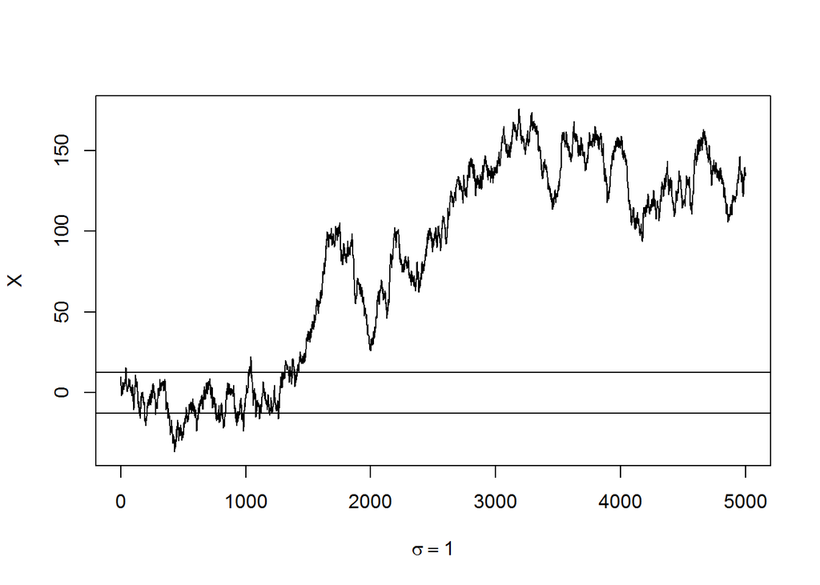

```r
refline <- qt(c(.025, .975), df=n)
plot(x, type="l",xlab=bquote(sigma == 1),ylab="X", ylim=range(x))
abline(h=refline)
```

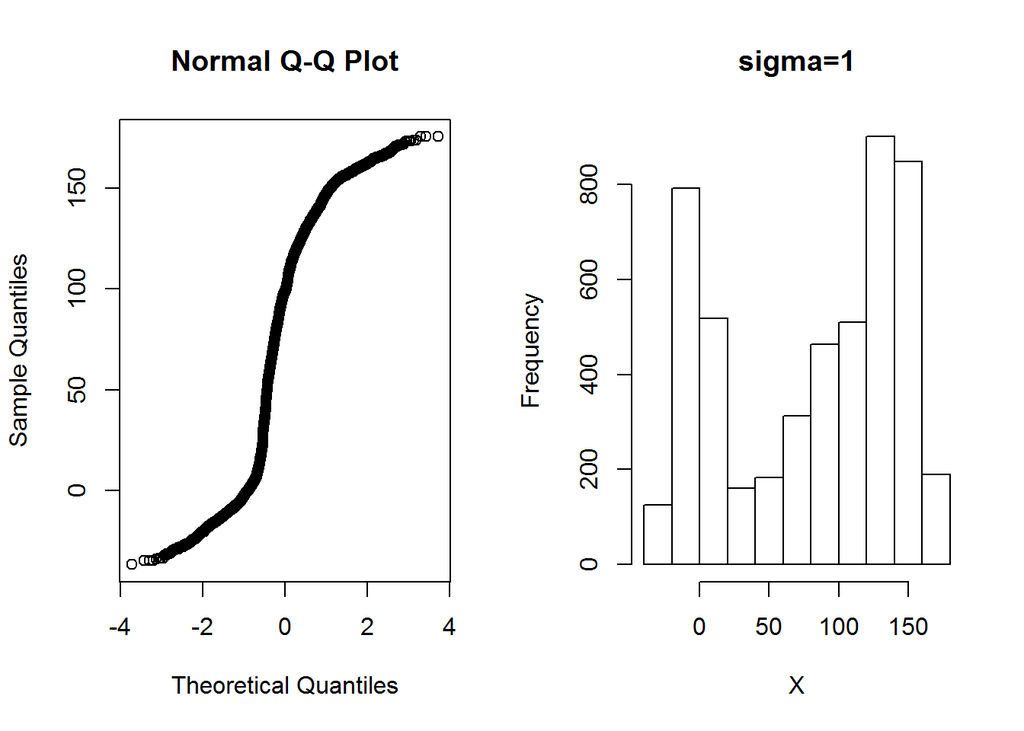

```r
par(mfrow=c(1,2))
qqnorm(x)#绘制sigma=1的Q-Q图
hist(x,xlab="X",main="sigma=1")#绘制sigma=1的直方图
```

Assignment 11-23

## Question 1

For exercise 9.6, use the Gelman-Rubin method to monitor convergence of the chain, and run the chain until the chain has converged approximately to the target distribution according to $\hat{R} < 1.2$

## Answer 3

1.Calculate joint probablity according to the sample.

```r
set.seed(1)
joint_probablity <- function( theta,x ) {
    probablity=(2+theta)^x[1] * (1-theta)^(x[2]+x[3]) * theta^x[4]
    return(probablity)
}
```

2.Write a function to generate a Markov chain of theta.

```r
theta_chain <- function(n) {
    xdata = c( 125, 18, 20, 34 ) #observed multinom. data
    theta = numeric(n)
    theta[1] = runif(1) #initialize: sample from prior on theta
    k = 0
    u = runif(n)

    for (t in 2:n) {
        xt = theta[t-1]
        alpha = xt/(1-xt)
        y <- rbeta(1, shape1=alpha, shape2=1 )
        numer = joint_probablity( y,xdata ) * dbeta( xt, y/(1-y), 1)
        denom = joint_probablity( xt,xdata ) * dbeta( y, alpha, 1)
        if ( u[t] <= numer/denom )
            theta[t] = y else {
            theta[t] = theta[t-1]
            k = k + 1
        }
    }
    return(theta)
}
```

3. Write a function to get Gelman Rubin statistic

```r
Gelman.Rubin <- function(psi) {
    # psi[i,j] is the statistic psi(X[i,1:j])
    # for chain in i-th row of X
    psi <- as.matrix(psi)
    n <- ncol(psi)
    k <- nrow(psi)
    psi.means <- rowMeans(psi) #row means
    B <- n * var(psi.means) #between variance est.
    psi.w <- apply(psi, 1, "var") #within variances
    W <- mean(psi.w) #within est.
    v.hat <- W*(n-1)/n + (B/n) #upper variance est.
    r.hat <- v.hat / W #G-R statistic
    return(r.hat)
}
```

```r
k <- 4 #number of chains to generate
n <- 8000 #length of chains
b <- 1000 #burn-in length


#generate the chains
X <- matrix(0, nrow=k, ncol=n)
for (i in 1:k)
    X[i, ] <- theta_chain(n)

#compute diagnostic statistics
psi <- t(apply(X, 1, cumsum))
for (i in 1:nrow(psi))
    psi[i,] <- psi[i,] / (1:ncol(psi))
print(Gelman.Rubin(psi))
```

```
## [1] 1.04097
```

For the Gelman.Rubin statistic is less than 1.2, so the chain of theta has converged approximately to the target distribution according to $\hat{R}<1.2$.

Draw the graph of chains of theta and rhat.

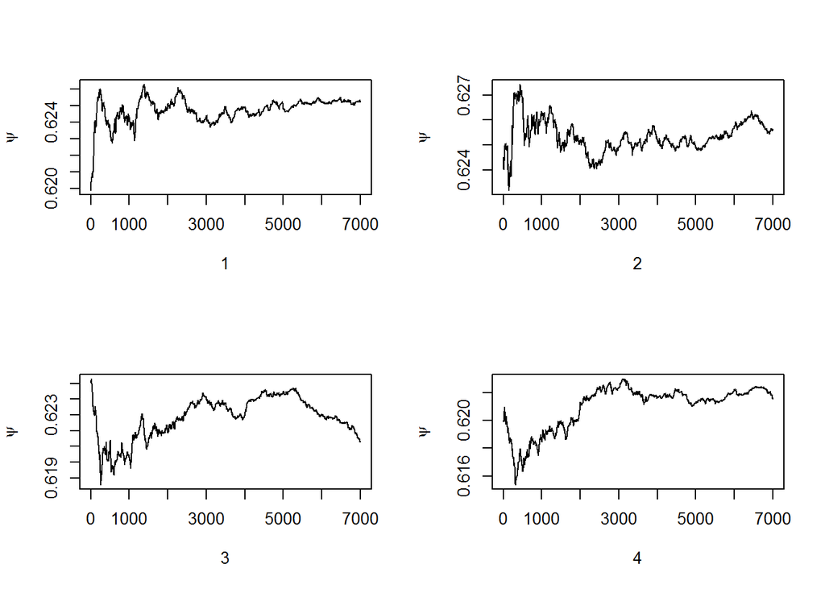

```r
#plot psi for the four chains
par(mfrow=c(2,2))
for (i in 1:k)
    plot(psi[i, (b+1):n], type="l",
        xlab=i, ylab=bquote(psi))
```

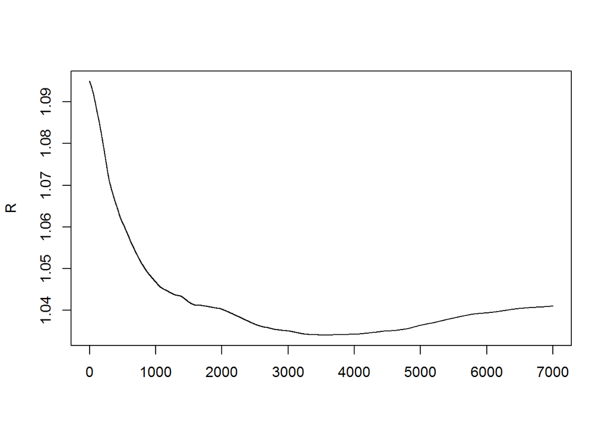

```r
par(mfrow=c(1,1)) #restore default

#plot the sequence of R-hat statistics
rhat <- rep(0, n)
for (j in (b+1):n)
    rhat[j] <- Gelman.Rubin(psi[,1:j])
plot(rhat[(b+1):n], type="l", xlab="", ylab="R")
abline(h=1.2, lty=2)
```

## Question 2

Find the intersection points $A(k)$ in $(0,\sqrt{k})$ of the curves
$$S_{k-1}(a)=P(t(k-1)>\sqrt{\frac{a^2(k-1)}{k-a^2}})$$
and
$$S_{k}(a)=P(t(k)>\sqrt{\frac{a^2k}{k+1-a^2}})$$
for $k = 4 : 25,100,500,1000$, where $t(k)$ is a Student t random variable with k degrees of freedom. (These intersection points determine the critical values for a t-test for scale-mixture errors proposed by Sz´ekely [260].)

## Answer 2

1. Generate a function to compare the difference of $S_k$ and $S_{k-1}$.

```r
k = c( 4:25, 100, 500, 1000 )
object = function( a, df ){
    num_1 = sqrt( (a^2)*(df-1)/(df - a^2) )
    S_kminus1 = pt( q=num_1, df=df-1, lower.tail = FALSE)
    num_2 = sqrt( (a^2)*df/(df + 1 - a^2) )
    S_k = pt( q=num_2, df=df, lower.tail = FALSE)

    return( S_k - S_kminus1 )
}
```

2. Draw a graph to tell the interval of the root approximately.

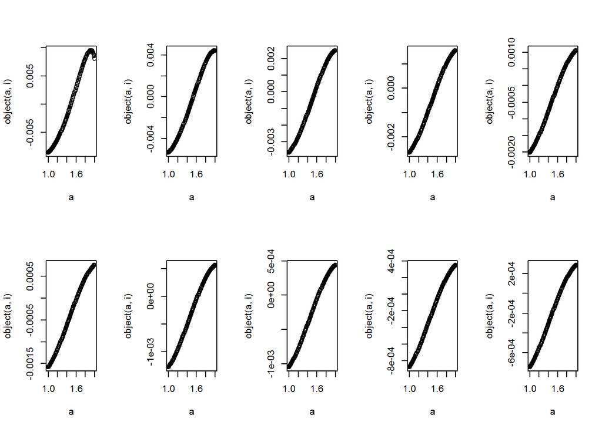

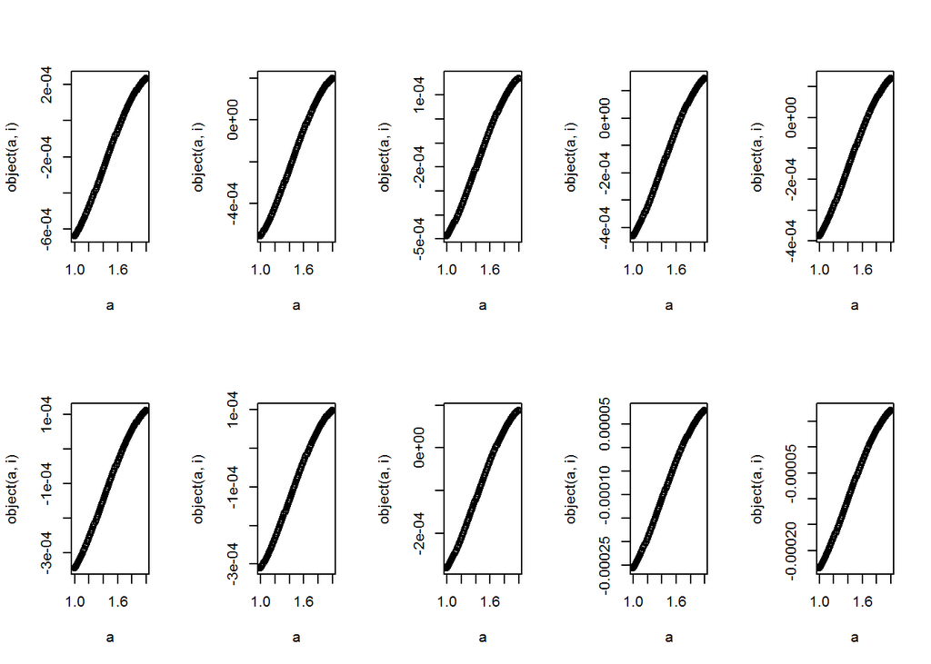

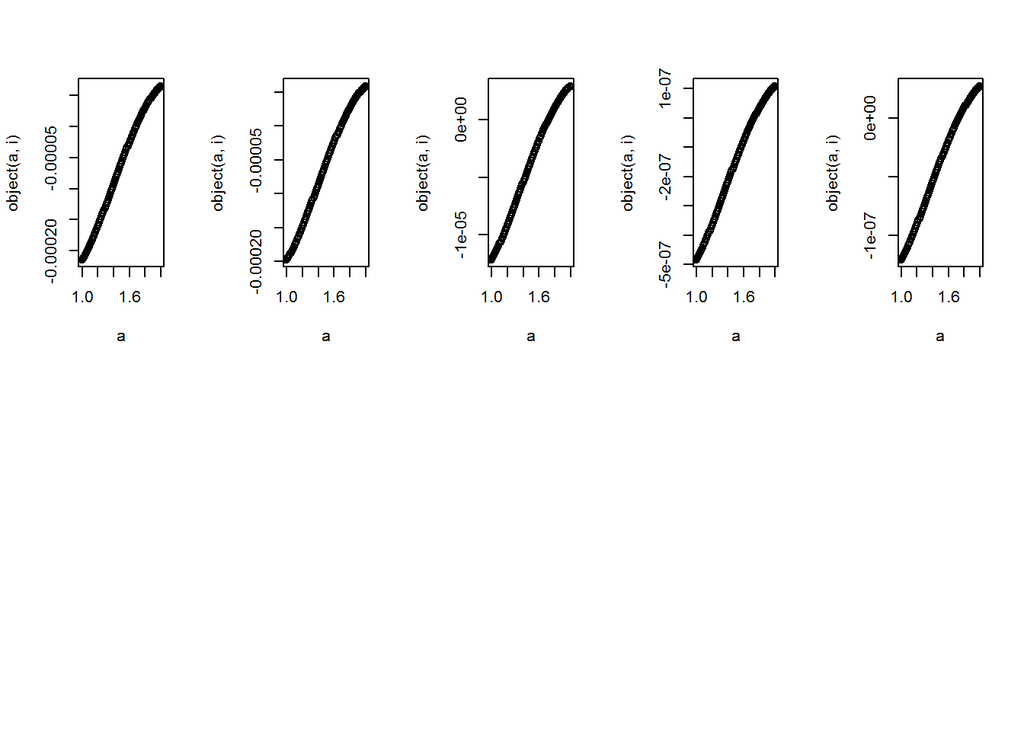

```r
par(mfrow=c(2,5))
for (i in k) {
    a=seq(1,2,0.01)
    plot(a,object(a,i))
}
```

3. According to the graph above, the interval lies in (1,2), so we can find the root.

```r
for ( i in 1:length(k) ) {
    root=uniroot(object, lower=1, upper=2, df=k[i])$root
    print( c( k[i], root ) )
}
```

```
## [1] 4.000000 1.492103
## [1] 5.000000 1.533556
## [1] 6.000000 1.562744
## [1] 7.00000 1.58443
## [1] 8.000000 1.601185
## [1] 9.000000 1.614521
## [1] 10.00000  1.62539
## [1] 11.000000  1.634419
## [1] 12.000000  1.642038
## [1] 13.000000  1.648554
## [1] 14.00000  1.65419
## [1] 15.000000  1.659114
## [1] 16.000000  1.663452
## [1] 17.000000  1.667303
## [1] 18.000000  1.670745
## [1] 19.00000  1.67384
## [1] 20.000000  1.676637
## [1] 21.000000  1.679178
## [1] 22.000000  1.681496
## [1] 23.00000  1.68362
## [1] 24.000000  1.685572
## [1] 25.000000  1.687373
## [1] 100.000000   1.720608
## [1] 500.000000   1.729755
## [1] 1000.000000    1.730907
```

Assignment 11-30

## Question 1

Write a function to compute the cdf of the Cauchy distribution, which has density
$$\frac{1}{\theta\pi(1+[(X-\eta)/\theta]^2)} ,-\infty < x < \infty,$$
where $\theta>0$. Compare your results to the results from the R function pcauchy. (Also see the source code in pcauchy.c.)

## Answer 1

1. Write a function to generate cauthy distribution

```r
cauchy_distribution = function(q, eta=0, theta=1) {
    cauthy_density = function(x,eta,theta){
        1/(theta*pi*(1 + ((x-eta)/theta)^2))
    }
    result = integrate( f=cauthy_density,lower=-Inf, upper=q,
                        rel.tol=.Machine$double.eps^0.25,
                        eta=eta, theta=theta )

    return( result$value )
}
```

2.Compare with the standard cauchy distribution :

```r
x = matrix( seq(-5,5), ncol=1 )
cbind( x, apply(x, MARGIN=1, FUN=cauchy_distribution), pcauchy(x) )
```

```
##       [,1]       [,2]       [,3]
##  [1,]   -5 0.06283296 0.06283296
##  [2,]   -4 0.07797913 0.07797913
##  [3,]   -3 0.10241638 0.10241638
##  [4,]   -2 0.14758362 0.14758362
##  [5,]   -1 0.25000000 0.25000000
##  [6,]    0 0.50000000 0.50000000
##  [7,]    1 0.75000000 0.75000000
##  [8,]    2 0.85241638 0.85241638
##  [9,]    3 0.89758362 0.89758362
## [10,]    4 0.92202087 0.92202087
## [11,]    5 0.93716704 0.93716704
```

```r
a=apply(x, MARGIN=1, FUN=cauchy_distribution)
```

compare with standard cauchy distribution with different eta parameter.

```r
cbind( x, apply( x, MARGIN=1, FUN=cauchy_distribution, eta=2 ),pcauchy(x,location=2) )
```

```
##       [,1]       [,2]       [,3]
##  [1,]   -5 0.04516724 0.04516724
##  [2,]   -4 0.05256846 0.05256846
##  [3,]   -3 0.06283296 0.06283296
##  [4,]   -2 0.07797913 0.07797913
##  [5,]   -1 0.10241638 0.10241638
##  [6,]    0 0.14758362 0.14758362
##  [7,]    1 0.25000000 0.25000000
##  [8,]    2 0.50000000 0.50000000
##  [9,]    3 0.75000000 0.75000000
## [10,]    4 0.85241638 0.85241638
## [11,]    5 0.89758362 0.89758362
```

compare with standard cauchy distribution with different theta parameter.

```r
cbind( x, apply( x, MARGIN=1, FUN=cauchy_distribution, theta=2 ),pcauchy(x,scale=2) )
```

```
##       [,1]      [,2]      [,3]
##  [1,]   -5 0.1211189 0.1211189
##  [2,]   -4 0.1475836 0.1475836
##  [3,]   -3 0.1871670 0.1871670
##  [4,]   -2 0.2500000 0.2500000
##  [5,]   -1 0.3524164 0.3524164
##  [6,]    0 0.5000000 0.5000000
##  [7,]    1 0.6475836 0.6475836
##  [8,]    2 0.7500000 0.7500000
##  [9,]    3 0.8128330 0.8128330
## [10,]    4 0.8524164 0.8524164
## [11,]    5 0.8788811 0.8788811
```

According to the result above, cauthy distribution we generate is same with standard cauthy distribution.

## Question 2

A-B-O blood type problem Let the three alleles be A, B, and O.

| Genotype | AA | BB | OO | AO | BO | AB | AA |
| --- | --- | --- | --- | --- | --- | --- | --- |
| Frequency | p2 | q2 | r2 | 2pr | 2qr | 2pq | 1 |
| Count | nAA | nBB | nOO | nAO | nBO | nAB | n |

Observed data: $n_{A\cdot}=n_{AA}+n_{AO}=28$ (A-type), $n_{B\cdot}=n_{BB}+n_{BO}=24$ (B-type), $n_{OO}=41$ (O-type), $n_{AB}=70$ (AB-type). Use EM algorithm to solve MLE of $p$ and $q$ (consider missing data $n_{AA}$ and $n_{BB}$). Record the maximum likelihood values in M-steps, are they increasing?

## Answer 2

### Complete data log-likelihood function.

$$\log L(x,p)= n_{AA}\log(p_A^2)+n_{AO}\log(p_Ap_O) + n_{AB}\log(p_Ap_B) + n_{BB}\log{p_Bp_B} + n{BO}\log(p_Bp_O) + n_{OO}\log(p_Op_O)$$
1. initial parameter

```r
x = c(28, 24, 41,70)
n = rep(0,6)
p = rep(1/3,3)
m = 20
```

2. Compute the expectation

```r
expectation = function(x,p){
    n.aa = (x[1]*(p[1]^2))/((p[1]^2)+2*p[1]*p[3])
    n.ao = (2*x[1]*p[1]*p[3])/((p[1]^2)+2*p[1]*p[3])
    n.bb = (x[2]*(p[2]^2))/((p[2]^2)+2*p[2]*p[3])
    n.bo = (2*x[2]*p[2]*p[3])/((p[2]^2)+2*p[2]*p[3])

    n = c(n.aa,n.ao,n.bb,n.bo,x[3],x[4])
    return(n)
}
```

3. Maximize the expectation.

```r
maximization = function(x,n){
    p.a = (2*n[1]+n[2]+n[3])/(2*sum(x))
    p.b = (2*n[4]+n[5]+n[2])/(2*sum(x))
    p.o = (2*n[6]+n[3]+n[5])/(2*sum(x))
    p = c(p.a,p.b,p.o)
    return(p)
}
```

4. Iteration of em algorithm.

```r
record_mle= numeric(m)
for(i in 1:m){
    n = expectation(x,p)
    p = maximization(x,n)
    record_mle[i]=(p[1]^(2*n[1]))*((2*p[1]*p[3])^(n[2]))*(p[2]^(2*n[3]))*((2*p[2]*p[3])^(n[4]))*((2*p[1]*p[2])^n[5])*(p[3]^(2*n[6]))
}


p
```

```
## [1] 0.1094766 0.3192316 0.5712918
```

```r
record_mle
```

```
##  [1] 1.216592e-126 1.154199e-123 2.506733e-123 2.482543e-123 2.491752e-123
##  [6] 2.491295e-123 2.491352e-123 2.491348e-123 2.491348e-123 2.491348e-123
## [11] 2.491348e-123 2.491348e-123 2.491348e-123 2.491348e-123 2.491348e-123
## [16] 2.491348e-123 2.491348e-123 2.491348e-123 2.491348e-123 2.491348e-123
```

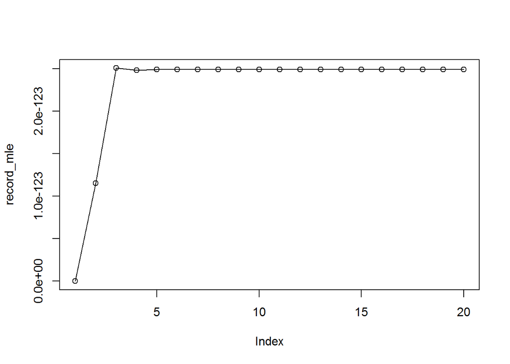

```r
plot(record_mle)
lines(record_mle)
```

Assignment 12-07

## Question 1

3. Use both for loops and lapply() to fit linear models to the mtcars using the formulas stored in this list:

```r
formulas <- list(
    mpg ~ disp,
    mpg ~ I(1 / disp),
    mpg ~ disp + wt,
    mpg ~ I(1 / disp) + wt
)
```

## Answer 1

1.Use for loops to fit linear models

```r
lm_forloop <- vector("list", length(formulas))
for (i in seq_along(formulas)){
    lm_forloop[[i]] <- lm(formulas[[i]], data = mtcars)
}

lm_forloop
```

```
## [[1]]
##
## Call:
## lm(formula = formulas[[i]], data = mtcars)
##
## Coefficients:
## (Intercept)         disp
##    29.59985     -0.04122
##
##
## [[2]]
##
## Call:
## lm(formula = formulas[[i]], data = mtcars)
##
## Coefficients:
## (Intercept)    I(1/disp)
##       10.75      1557.67
##
##
## [[3]]
##
## Call:
## lm(formula = formulas[[i]], data = mtcars)
##
## Coefficients:
## (Intercept)         disp           wt
##    34.96055     -0.01772     -3.35083
##
##
## [[4]]
##
## Call:
## lm(formula = formulas[[i]], data = mtcars)
##
## Coefficients:
## (Intercept)    I(1/disp)           wt
##      19.024     1142.560       -1.798
```

2.Use lapply() to fit linear models

```r
lm_lapply <- lapply(formulas, function(x) lm(formula = x, data = mtcars))

lm_lapply
```

```
## [[1]]
##
## Call:
## lm(formula = x, data = mtcars)
##
## Coefficients:
## (Intercept)         disp
##    29.59985     -0.04122
##
##
## [[2]]
##
## Call:
## lm(formula = x, data = mtcars)
##
## Coefficients:
## (Intercept)    I(1/disp)
##       10.75      1557.67
##
##
## [[3]]
##
## Call:
## lm(formula = x, data = mtcars)
##
## Coefficients:
## (Intercept)         disp           wt
##    34.96055     -0.01772     -3.35083
##
##
## [[4]]
##
## Call:
## lm(formula = x, data = mtcars)
##
## Coefficients:
## (Intercept)    I(1/disp)           wt
##      19.024     1142.560       -1.798
```

## Question 2

4. Fit the model mpg ~ disp to each of the bootstrap replicates of mtcars in the list below by using a for loop and lapply() . Can you do it without an anonymous function?

```r
bootstraps <- lapply(1:10, function(i) {
rows <- sample(1:nrow(mtcars), rep = TRUE)
mtcars[rows, ]
})
```

## Answer 2

1.Fit the model mpg ~ disp by using lapply()

```r
lapply_fit <- lapply(bootstraps, function(x) lm(mpg~disp, data=x))

lapply_fit
```

```
## [[1]]
##
## Call:
## lm(formula = mpg ~ disp, data = x)
##
## Coefficients:
## (Intercept)         disp
##    31.77734     -0.04722
##
##
## [[2]]
##
## Call:
## lm(formula = mpg ~ disp, data = x)
##
## Coefficients:
## (Intercept)         disp
##    33.09234     -0.05591
##
##
## [[3]]
##
## Call:
## lm(formula = mpg ~ disp, data = x)
##
## Coefficients:
## (Intercept)         disp
##    31.47131     -0.04941
##
##
## [[4]]
##
## Call:
## lm(formula = mpg ~ disp, data = x)
##
## Coefficients:
## (Intercept)         disp
##    28.83233     -0.03797
##
##
```

[output cut: 43 more lines]

```
## lm(formula = mpg ~ disp, data = x)
##
## Coefficients:
## (Intercept)         disp
##    27.81942     -0.03412
##
##
## [[10]]
##
## Call:
## lm(formula = mpg ~ disp, data = x)
##
## Coefficients:
## (Intercept)         disp
##    29.65345     -0.04002
```

2.Fit the model mpg ~ disp by using a for loop.

```r
for_loop_fit <- vector("list", length(bootstraps))
for (i in seq_along(bootstraps)){
  for_loop_fit[[i]] <- lm(mpg ~ disp, data = bootstraps[[i]])
}

for_loop_fit
```

```
## [[1]]
##
## Call:
## lm(formula = mpg ~ disp, data = bootstraps[[i]])
##
## Coefficients:
## (Intercept)         disp
##    31.77734     -0.04722
##
##
## [[2]]
##
## Call:
## lm(formula = mpg ~ disp, data = bootstraps[[i]])
##
## Coefficients:
## (Intercept)         disp
##    33.09234     -0.05591
##
##
## [[3]]
##
## Call:
## lm(formula = mpg ~ disp, data = bootstraps[[i]])
##
## Coefficients:
## (Intercept)         disp
##    31.47131     -0.04941
##
##
## [[4]]
##
## Call:
## lm(formula = mpg ~ disp, data = bootstraps[[i]])
##
## Coefficients:
## (Intercept)         disp
##    28.83233     -0.03797
##
##
```

[output cut: 43 more lines]

```
## lm(formula = mpg ~ disp, data = bootstraps[[i]])
##
## Coefficients:
## (Intercept)         disp
##    27.81942     -0.03412
##
##
## [[10]]
##
## Call:
## lm(formula = mpg ~ disp, data = bootstraps[[i]])
##
## Coefficients:
## (Intercept)         disp
##    29.65345     -0.04002
```

## Question 3

For each model in the previous two exercises, extract $R^2$ using the function below.

```r
rsq <- function(mod) summary(mod)$r.squared
```

## Answer 3

```r
lapply(formulas, function(x) rsq(lm(formula=x, data=mtcars)))
```

```
## [[1]]
## [1] 0.7183433
##
## [[2]]
## [1] 0.8596865
##
## [[3]]
## [1] 0.7809306
##
## [[4]]
## [1] 0.8838038
```

```r
lapply(bootstraps, function(x) rsq(lm(mpg~disp, data=x)))
```

```
## [[1]]
## [1] 0.7799682
##
## [[2]]
## [1] 0.7955772
##
## [[3]]
## [1] 0.8198789
##
## [[4]]
## [1] 0.724918
##
## [[5]]
## [1] 0.6837225
##
## [[6]]
## [1] 0.7354968
##
## [[7]]
## [1] 0.7540727
##
## [[8]]
## [1] 0.8218294
##
## [[9]]
## [1] 0.7143574
##
## [[10]]
## [1] 0.7000557
```

## Question 4

3. The following code simulates the performance of a t-test for non-normal data. Use sapply() and an anonymous function to extract the p-value from every trial.

```r
trials <- replicate(
    100,
    t.test(rpois(10, 10), rpois(7, 10)),
    simplify = FALSE
)
```

Extra challenge: get rid of the anonymous function by using [[ directly.

## Answer 4

```r
sapply(trials, function(x) x[["p.value"]])
```

```
##   [1] 0.28230680 0.08947603 0.48117423 0.31483093 0.77257892 0.82408485
##   [7] 0.55285297 0.19302206 0.46279261 0.44915446 0.30643200 0.26840488
##  [13] 0.58961936 0.88461357 0.41662840 0.60720020 0.58674221 0.63190358
##  [19] 0.24908219 0.83079837 0.71290961 0.94607296 0.43222262 0.08616828
##  [25] 0.82114705 0.96778142 0.34072867 0.26276336 0.22628597 0.56873515
##  [31] 0.24803506 0.92219580 0.68074403 0.60504431 0.25334434 0.49077948
##  [37] 0.32160993 0.16706666 0.37340315 0.97245307 0.17490288 0.41989037
##  [43] 0.95720755 0.40644095 0.39883159 0.24829398 0.25960492 0.89843178
##  [49] 0.49651560 0.11629643 0.90076235 0.17553689 0.87247717 0.72911406
##  [55] 0.92440342 0.49822585 0.36512004 0.60013047 0.53341030 0.32224123
##  [61] 0.21314602 0.48888265 0.79514991 0.37100803 0.36791168 0.51125142
##  [67] 0.86611386 0.52102760 0.77626340 0.10758149 0.80841809 0.11804504
##  [73] 0.53085475 0.19156954 0.00626417 0.49405144 0.23183405 0.49479581
##  [79] 0.25952458 0.28041080 0.72157188 0.48218766 0.80384105 0.51499035
##  [85] 0.09681238 0.92527870 0.59717358 0.98831912 0.50055463 0.22123571
##  [91] 0.54418723 0.41542169 0.62296860 0.78839734 0.08480755 0.01330250
##  [97] 0.61659952 0.71640451 0.74542857 0.71567686
```

```r
sapply(trials, "[[", "p.value")
```

```
##   [1] 0.28230680 0.08947603 0.48117423 0.31483093 0.77257892 0.82408485
##   [7] 0.55285297 0.19302206 0.46279261 0.44915446 0.30643200 0.26840488
##  [13] 0.58961936 0.88461357 0.41662840 0.60720020 0.58674221 0.63190358
##  [19] 0.24908219 0.83079837 0.71290961 0.94607296 0.43222262 0.08616828
##  [25] 0.82114705 0.96778142 0.34072867 0.26276336 0.22628597 0.56873515
##  [31] 0.24803506 0.92219580 0.68074403 0.60504431 0.25334434 0.49077948
##  [37] 0.32160993 0.16706666 0.37340315 0.97245307 0.17490288 0.41989037
##  [43] 0.95720755 0.40644095 0.39883159 0.24829398 0.25960492 0.89843178
##  [49] 0.49651560 0.11629643 0.90076235 0.17553689 0.87247717 0.72911406
##  [55] 0.92440342 0.49822585 0.36512004 0.60013047 0.53341030 0.32224123
##  [61] 0.21314602 0.48888265 0.79514991 0.37100803 0.36791168 0.51125142
##  [67] 0.86611386 0.52102760 0.77626340 0.10758149 0.80841809 0.11804504
##  [73] 0.53085475 0.19156954 0.00626417 0.49405144 0.23183405 0.49479581
##  [79] 0.25952458 0.28041080 0.72157188 0.48218766 0.80384105 0.51499035
##  [85] 0.09681238 0.92527870 0.59717358 0.98831912 0.50055463 0.22123571
##  [91] 0.54418723 0.41542169 0.62296860 0.78839734 0.08480755 0.01330250
##  [97] 0.61659952 0.71640451 0.74542857 0.71567686
```

## Question 5

6. Implement a combination of Map() and vapply() to create an lapply() variant that iterates in parallel over all of its inputs and stores its outputs in a vector (or a matrix). What arguments should the function take?

## Answer 5

According to the question, we want to combine Map() and vapply() to create a function to make both input and output are both vector(or a matrix). Apparently, Map() can take vector as its input, and vapply() can take vector as its output. So the code as below.

```r
map_vapply <- function(X, FUN, FUN.VALUE, simplify = FALSE){
    out <- Map(function(x) vapply(x, FUN, FUN.VALUE), X)
    return(out)
}
```

Obviously, arguments should take both map() and vapply() function take originally.

Assignment 12-14

## Question 1

1. Make a faster version of chisq.test() that only computes the chi-square test statistic when the input is two numeric vectors with no missing values.

## Answer 1

1.Compute expected value

```r
expected <- function(colsum, rowsum, total) {
    (colsum/total)*(rowsum/total)*total
}
```

2.Compute chisquare statistics.

```r
chi_stat <- function(observed, expected) {
    ((observed-expected)^2)/expected
}
```

3. Difine a chi_test function by myself.

```r
chisq_test <- function(x, y) {
    total <- sum(x) + sum(y)
    rowsum_1 <- sum(x)
    rowsum_2 <- sum(y)
    colsum = x+y
    expected_1=mapply(expected, colsum,rowsum_1, total)
    expected_2=mapply(expected, colsum,rowsum_2, total)
    chi_1=mapply(chi_stat, x,expected_1)
    chi_2=mapply(chi_stat, x,expected_2)
    chistat=sum(chi_1+chi_2)

    return(chistat)
}

print(chisq_test(c(13,27,19,10), c(15,17,21,27)))
```

```
## [1] 11.07895
```

```r
print(chisq.test(c(13,27,19,10), c(15,17,21,27)))
```

```
##
##  Pearson's Chi-squared test
##
## data:  c(13, 27, 19, 10) and c(15, 17, 21, 27)
## X-squared = 12, df = 9, p-value = 0.2133
```

```r
print(microbenchmark::microbenchmark(
    chisq_test(c(13,27,19,10), c(15,17,21,27)),
    chisq.test(c(13,27,19,10), c(15,17,21,27))
))
```

[output not shown]

[output cut: 244 more lines]

[output not shown]

```
## Unit: microseconds
##                                              expr     min       lq
##  chisq_test(c(13, 27, 19, 10), c(15, 17, 21, 27)) 103.862 107.9670
##  chisq.test(c(13, 27, 19, 10), c(15, 17, 21, 27)) 951.589 964.3155
##       mean   median        uq      max neval
##   137.5416 122.9520  130.3405  235.229   100
##  1122.1688 979.5045 1164.8550 1614.991   100
```

Warning message is because of chisq.test result. Obviously, chisq_test generated by myself is faster then chisq.test.

## Question 2

Can you make a faster version of table() for the case of an input of two integer vectors with no missing values? Can you use it to speed up your chi-square test?

## Answer 2

```r
table_fast <- function(x, y) {
    x_num <- unique(x)
    y_num <- unique(y)
    mat <- matrix(0, length(x_num), length(y_num))
    for (i in seq_along(x)) {
        mat[which(x_num == x[[i]]), which(y_num == y[[i]])] <-
        mat[which(x_num == x[[i]]),  which(y_num == y[[i]])] + 1
    }
    dimnames <- list(x_num, y_num)
    tab <- array(mat, dim = dim(mat), dimnames = dimnames)
    class(tab) <- "table"
    return(tab)
}

a=c(3,7,15)
microbenchmark::microbenchmark(table(a,a), table_fast(a, a))
```

```
## Unit: microseconds
##              expr     min       lq     mean   median       uq       max
##       table(a, a) 250.008 254.5235 261.7982 257.6025 262.9395   438.026
##  table_fast(a, a)  49.263  51.9315 207.1578  54.1890  55.8310 15361.709
##  neval
##    100
##    100
```

Apparently,we made a fast table2().